# Rescorla-Wagner Model

Frank Mollica & Shirlene Wade

# Variables

Consider presenting a light to a dog before food.

Light $\to$ Food

$V_L$ is the association strength between the light and the food.

$\alpha_L$ is the salience of the light.

$\beta$ is the learning rate (or step size).

$\lambda$ is the maximum associability of any event with the food.

In this scenario, we update associations according to the following equation:

$\Delta V_L = \alpha_L\beta(\lambda-\sum_y V_y)$

# Learning Example

Light $\to$ Food

$V_L = 0.1$

$\alpha_L = 1$

$\beta = 0.5$

$\lambda = 1$

```r
w = data.frame(Object='light', V=0.1, Time=0)
beta = 0.5

# Time 1
w = observe(w, 'light', 1, 1, beta)
```

```
## delta V = 1 * 0.5 * (1 - 0.1) = 0.45
## V_light = 0.55
```

```r
# Time 2
w = observe(w, 'light', 2, 1, beta)
```

```
## delta V = 1 * 0.5 * (1 - 0.55) = 0.225
## V_light = 0.775
```

```r
# Time 3
w = observe(w, 'light', 3, 1, beta)
```

```
## delta V = 1 * 0.5 * (1 - 0.775) = 0.1125
## V_light = 0.8875
```

```r
# Time 4
w = observe(w, 'light', 4, 1, beta)
```

```
## delta V = 1 * 0.5 * (1 - 0.8875) = 0.05625
## V_light = 0.94375
```

```r
# Time 5
w = observe(w, 'light', 5, 1, beta)
```

```
## delta V = 1 * 0.5 * (1 - 0.94375) = 0.028125
## V_light = 0.971875
```

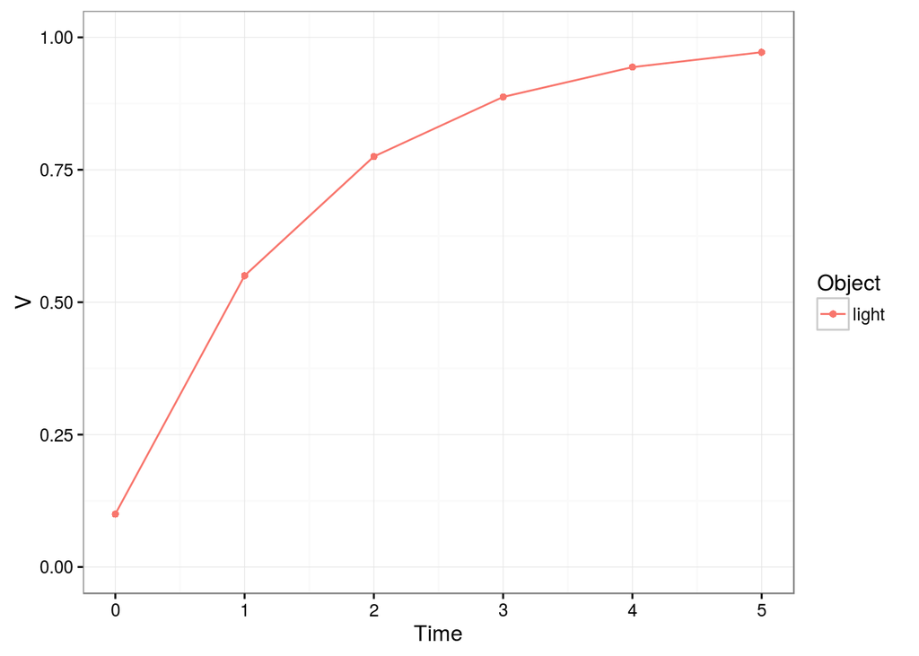

```r
ggplot(w[w$Object != '',], aes(Time, V, shape=Object, color=Object)) +
  geom_line() +
  geom_point() +
  theme_bw() + ylim(0, 1)
```

## Change in maximum Associability?

$V_L = 0.1$

$\alpha_L = 1$

$\beta = 0.5$

$\lambda = 0.5$

```r
w = data.frame(Object='light', V=0.1, Time=0)
beta = 0.5

# Time 1
w = observe(w, 'light', 1, 1, beta)
```

```
## delta V = 1 * 0.5 * (0.5 - 0.1) = 0.2
## V_light = 0.3
```

```r
# Time 2
w = observe(w, 'light', 2, 1, beta)
```

```
## delta V = 1 * 0.5 * (0.5 - 0.3) = 0.1
## V_light = 0.4
```

```r
# Time 3
w = observe(w, 'light', 3, 1, beta)
```

```
## delta V = 1 * 0.5 * (0.5 - 0.4) = 0.05
## V_light = 0.45
```

```r
# Time 4
w = observe(w, 'light', 4, 1, beta)
```

```
## delta V = 1 * 0.5 * (0.5 - 0.45) = 0.025
## V_light = 0.475
```

```r
# Time 5
w = observe(w, 'light', 5, 1, beta)
```

```
## delta V = 1 * 0.5 * (0.5 - 0.475) = 0.0125
## V_light = 0.4875
```

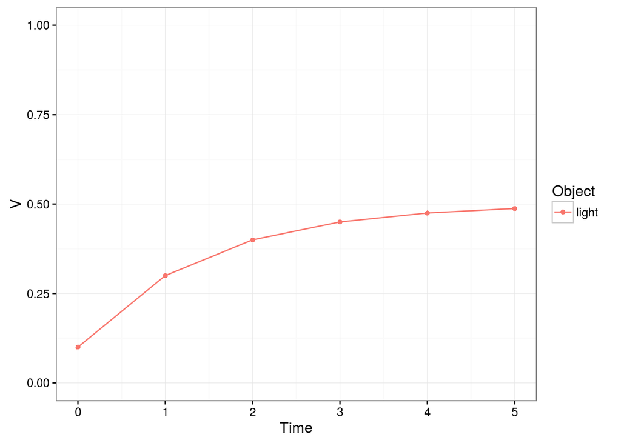

```r
ggplot(w[w$Object != '',], aes(Time, V, shape=Object, color=Object)) +
  geom_line() +
  geom_point() +
  theme_bw() + ylim(0, 1)
```

## Change in salience?

$V_L = 0.1$

$\alpha_L = 0.5$

$\beta = 0.5$

$\lambda = 1$

```r
w = data.frame(Object='light', V=0.1, Time=0)
beta = 0.5

# Time 1
w = observe(w, 'light', 1, 0.5, beta)
```

```
## delta V = 0.5 * 0.5 * (1 - 0.1) = 0.225
## V_light = 0.325
```

```r
# Time 2
w = observe(w, 'light', 2, 0.5, beta)
```

```
## delta V = 0.5 * 0.5 * (1 - 0.325) = 0.16875
## V_light = 0.49375
```

```r
# Time 3
w = observe(w, 'light', 3, 0.5, beta)
```

```
## delta V = 0.5 * 0.5 * (1 - 0.49375) = 0.1265625
## V_light = 0.6203125
```

```r
# Time 4
w = observe(w, 'light', 4, 0.5, beta)
```

```
## delta V = 0.5 * 0.5 * (1 - 0.6203125) = 0.094921875
## V_light = 0.715234375
```

```r
# Time 5
w = observe(w, 'light', 5, 0.5, beta)
```

```
## delta V = 0.5 * 0.5 * (1 - 0.715234375) = 0.07119140625
## V_light = 0.78642578125
```

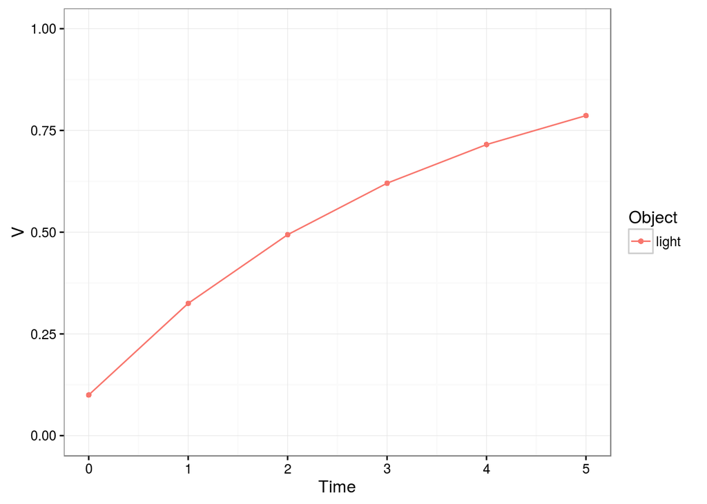

```r
ggplot(w[w$Object != '',], aes(Time, V, shape=Object, color=Object)) +
  geom_line() +
  geom_point() +
  theme_bw() + ylim(0, 1)
```

## Change in learning rate

$V_L = 0.1$

$\alpha_L = 1$

$\beta = 0.6$

$\lambda = 1$

```r
w = data.frame(Object='light', V=0.1, Time=0)
beta = 0.6

# Time 1
w = observe(w, 'light', 1, 1, beta)
```

```
## delta V = 1 * 0.6 * (1 - 0.1) = 0.54
## V_light = 0.64
```

```r
# Time 2
w = observe(w, 'light', 2, 1, beta)
```

```
## delta V = 1 * 0.6 * (1 - 0.64) = 0.216
## V_light = 0.856
```

```r
# Time 3
w = observe(w, 'light', 3, 1, beta)
```

```
## delta V = 1 * 0.6 * (1 - 0.856) = 0.0864
## V_light = 0.9424
```

```r
# Time 4
w = observe(w, 'light', 4, 1, beta)
```

```
## delta V = 1 * 0.6 * (1 - 0.9424) = 0.03456
## V_light = 0.97696
```

```r
# Time 5
w = observe(w, 'light', 5, 1, beta)
```

```
## delta V = 1 * 0.6 * (1 - 0.97696) = 0.013824
## V_light = 0.990784
```

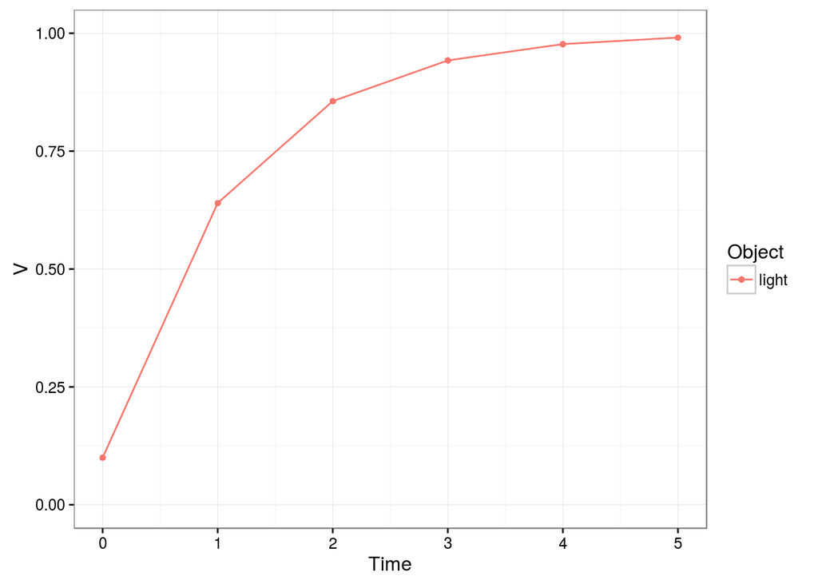

```r
ggplot(w[w$Object != '',], aes(Time, V, shape=Object, color=Object)) +
  geom_line() +
  geom_point() +
  theme_bw() + ylim(0, 1)
```

# Overshadowing

Light + Tone $\to$ Food

$V_L = 0.1$

$V_T = 0.1$

$\alpha_L = 1$

$\alpha_T = 0.5$

$\beta = 0.5$

$\lambda = 1$

```r
w = data.frame(Object=c('light', 'tone'), V=0.1, Time=0)
beta = 0.5


# Time 1
w = observe(w, 'light', 1, 1, beta)
```

```
## delta V = 1 * 0.5 * (1 - 0.2) = 0.4
## V_light = 0.5
```

```r
w = observe(w, 'tone', 1, 0.5, beta)
```

```
## delta V = 0.5 * 0.5 * (1 - 0.2) = 0.2
## V_tone = 0.3
```

```r
# Time 2
w = observe(w, 'light', 2, 1, beta)
```

```
## delta V = 1 * 0.5 * (1 - 0.8) = 0.1
## V_light = 0.6
```

```r
w = observe(w, 'tone', 2, 0.5, beta)
```

```
## delta V = 0.5 * 0.5 * (1 - 0.8) = 0.05
## V_tone = 0.35
```

```r
# Time 3
w = observe(w, 'light', 3, 1, beta)
```

```
## delta V = 1 * 0.5 * (1 - 0.95) = 0.025
## V_light = 0.625
```

```r
w = observe(w, 'tone', 3, 0.5, beta)
```

```
## delta V = 0.5 * 0.5 * (1 - 0.95) = 0.0125
## V_tone = 0.3625
```

```r
# Time 4
w = observe(w, 'light', 4, 1, beta)
```

```
## delta V = 1 * 0.5 * (1 - 0.9875) = 0.00624999999999998
## V_light = 0.63125
```

```r
w = observe(w, 'tone', 4, 0.5, beta)
```

```
## delta V = 0.5 * 0.5 * (1 - 0.9875) = 0.00312499999999999
## V_tone = 0.365625
```

```r
# Time 5
w = observe(w, 'light', 5, 1, beta)
```

```
## delta V = 1 * 0.5 * (1 - 0.996875) = 0.00156250000000002
## V_light = 0.6328125
```

```r
w = observe(w, 'tone', 5, 0.5, beta)
```

```
## delta V = 0.5 * 0.5 * (1 - 0.996875) = 0.000781250000000011
## V_tone = 0.36640625
```

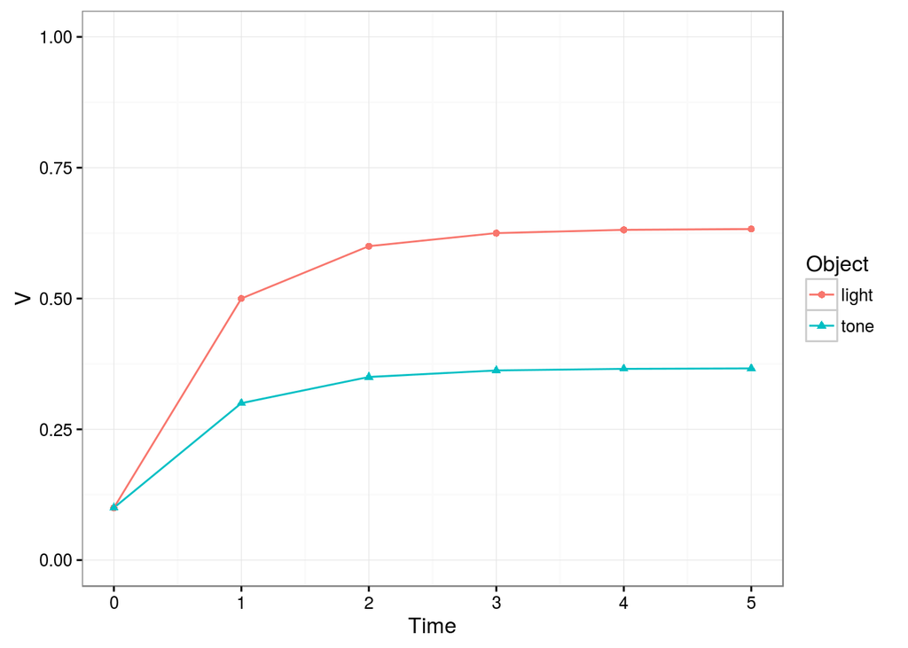

```r
ggplot(w[w$Object != '',], aes(Time, V, shape=Object, color=Object)) +
  geom_line() +
  geom_point() +
  theme_bw() + ylim(0, 1)
```

# Blocking

Light + Tone $\to$ Food

$V_L = 0.6$

$V_T = 0.1$

$\alpha_L = 1$

$\alpha_T = 1$

$\beta = 0.5$

$\lambda = 1$

```r
w = data.frame(Object=c('light', 'tone'), V=c(0.6, 0.1), Time=0)
beta = 0.5

# Time 1
w = observe(w, 'light', 1, 1, beta)
```

```
## delta V = 1 * 0.5 * (1 - 0.7) = 0.15
## V_light = 0.75
```

```r
w = observe(w, 'tone', 1, 1, beta)
```

```
## delta V = 1 * 0.5 * (1 - 0.7) = 0.15
## V_tone = 0.25
```

```r
# Time 2
w = observe(w, 'light', 2, 1, beta)
```

```
## delta V = 1 * 0.5 * (1 - 1) = 0
## V_light = 0.75
```

```r
w = observe(w, 'tone', 2, 1, beta)
```

```
## delta V = 1 * 0.5 * (1 - 1) = 0
## V_tone = 0.25
```

```r
# Time 3
w = observe(w, 'light', 3, 1, beta)
```

```
## delta V = 1 * 0.5 * (1 - 1) = 0
## V_light = 0.75
```

```r
w = observe(w, 'tone', 3, 1, beta)
```

```
## delta V = 1 * 0.5 * (1 - 1) = 0
## V_tone = 0.25
```

```r
# Time 4
w = observe(w, 'light', 4, 1, beta)
```

```
## delta V = 1 * 0.5 * (1 - 1) = 0
## V_light = 0.75
```

```r
w = observe(w, 'tone', 4, 1, beta)
```

```
## delta V = 1 * 0.5 * (1 - 1) = 0
## V_tone = 0.25
```

```r
# Time 5
w = observe(w, 'light', 5, 1, beta)
```

```
## delta V = 1 * 0.5 * (1 - 1) = 0
## V_light = 0.75
```

```r
w = observe(w, 'tone', 5, 1, beta)
```

```
## delta V = 1 * 0.5 * (1 - 1) = 0
## V_tone = 0.25
```

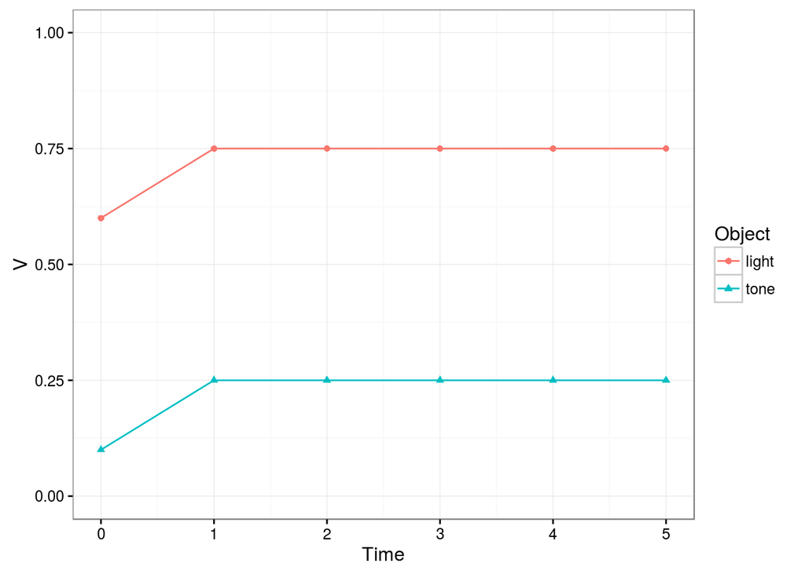

```r
ggplot(w[w$Object != '',], aes(Time, V, shape=Object, color=Object)) +
  geom_line() +
  geom_point() +
  theme_bw() + ylim(0, 1)
```

# Extinction

In extinction, the conditioned stimulus is presented without the unconditioned stimulus. The main difference in the math is that the maximum amount you could associate light to food in a trial is zero because there is no food in extinction.

Light $\to$ ~Food

$V_L = 1$

$\alpha_L = 1$

$\beta = 0.5$

$\lambda = 0$

```r
w = data.frame(Object='light', V=1, Time=0)
beta = 0.5

# Time 1
w = observe(w, 'light', 1, 1, beta)
```

```
## delta V = 1 * 0.5 * (0 - 1) = -0.5
## V_light = 0.5
```

```r
# Time 2
w = observe(w, 'light', 2, 1, beta)
```

```
## delta V = 1 * 0.5 * (0 - 0.5) = -0.25
## V_light = 0.25
```

```r
# Time 3
w = observe(w, 'light', 3, 1, beta)
```

```
## delta V = 1 * 0.5 * (0 - 0.25) = -0.125
## V_light = 0.125
```

```r
# Time 4
w = observe(w, 'light', 4, 1, beta)
```

```
## delta V = 1 * 0.5 * (0 - 0.125) = -0.0625
## V_light = 0.0625
```

```r
# Time 5
w = observe(w, 'light', 5, 1, beta)
```

```
## delta V = 1 * 0.5 * (0 - 0.0625) = -0.03125
## V_light = 0.03125
```

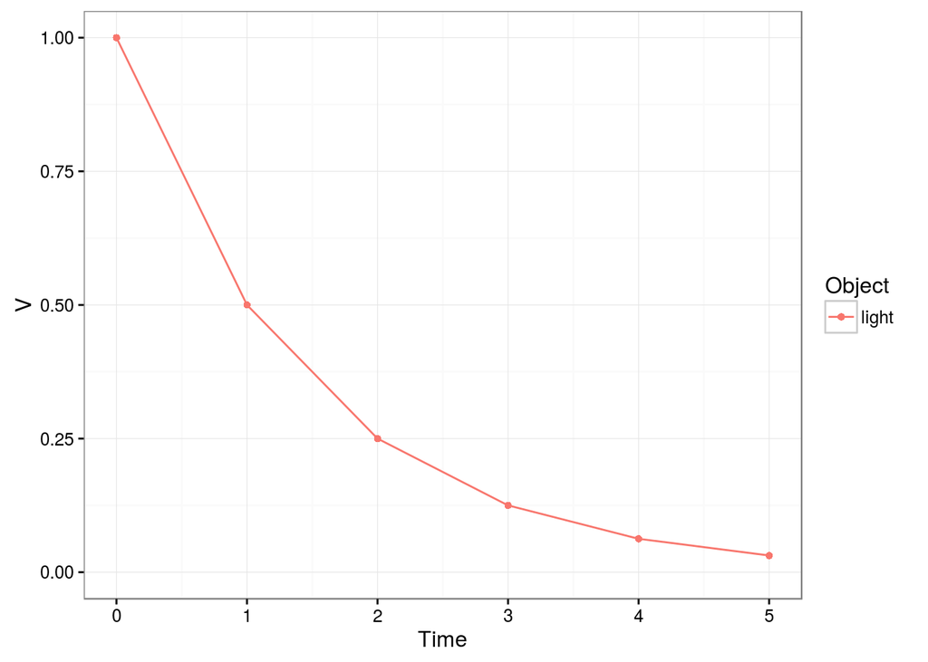

```r
ggplot(w[w$Object != '',], aes(Time, V, shape=Object, color=Object)) +
  geom_line() +
  geom_point() +
  theme_bw() + ylim(0, 1)
```

## Change in salience?

$\alpha_L = 0.5$

```r
w = data.frame(Object='light', V=1, Time=0)
beta = 0.5

# Time 1
w = observe(w, 'light', 1, 0.5, beta)
```

```
## delta V = 0.5 * 0.5 * (0 - 1) = -0.25
## V_light = 0.75
```

```r
# Time 2
w = observe(w, 'light', 2, 0.5, beta)
```

```
## delta V = 0.5 * 0.5 * (0 - 0.75) = -0.1875
## V_light = 0.5625
```

```r
# Time 3
w = observe(w, 'light', 3, 0.5, beta)
```

```
## delta V = 0.5 * 0.5 * (0 - 0.5625) = -0.140625
## V_light = 0.421875
```

```r
# Time 4
w = observe(w, 'light', 4, 0.5, beta)
```

```
## delta V = 0.5 * 0.5 * (0 - 0.421875) = -0.10546875
## V_light = 0.31640625
```

```r
# Time 5
w = observe(w, 'light', 5, 0.5, beta)
```

```
## delta V = 0.5 * 0.5 * (0 - 0.31640625) = -0.0791015625
## V_light = 0.2373046875
```

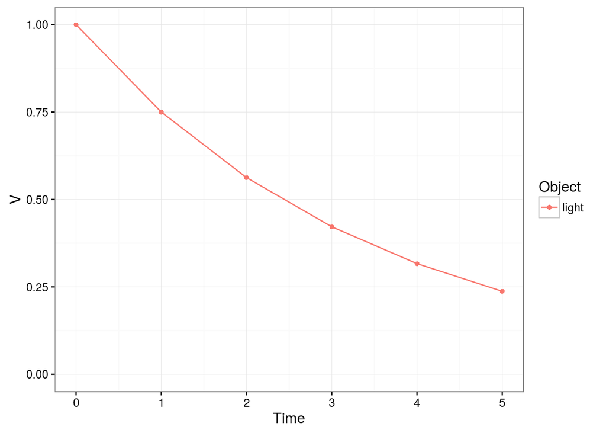

```r
ggplot(w[w$Object != '',], aes(Time, V, shape=Object, color=Object)) +
  geom_line() +
  geom_point() +
  theme_bw() + ylim(0, 1)
```

## Change in learning rate

$\beta = 0.6$

```r
w = data.frame(Object='light', V=1, Time=0)
beta = 0.6

# Time 1
w = observe(w, 'light', 1, 0.5, beta)
```

```
## delta V = 0.5 * 0.6 * (0 - 1) = -0.3
## V_light = 0.7
```

```r
# Time 2
w = observe(w, 'light', 2, 0.5, beta)
```

```
## delta V = 0.5 * 0.6 * (0 - 0.7) = -0.21
## V_light = 0.49
```

```r
# Time 3
w = observe(w, 'light', 3, 0.5, beta)
```

```
## delta V = 0.5 * 0.6 * (0 - 0.49) = -0.147
## V_light = 0.343
```

```r
# Time 4
w = observe(w, 'light', 4, 0.5, beta)
```

```
## delta V = 0.5 * 0.6 * (0 - 0.343) = -0.1029
## V_light = 0.2401
```

```r
# Time 5
w = observe(w, 'light', 5, 0.5, beta)
```

```
## delta V = 0.5 * 0.6 * (0 - 0.2401) = -0.07203
## V_light = 0.16807
```

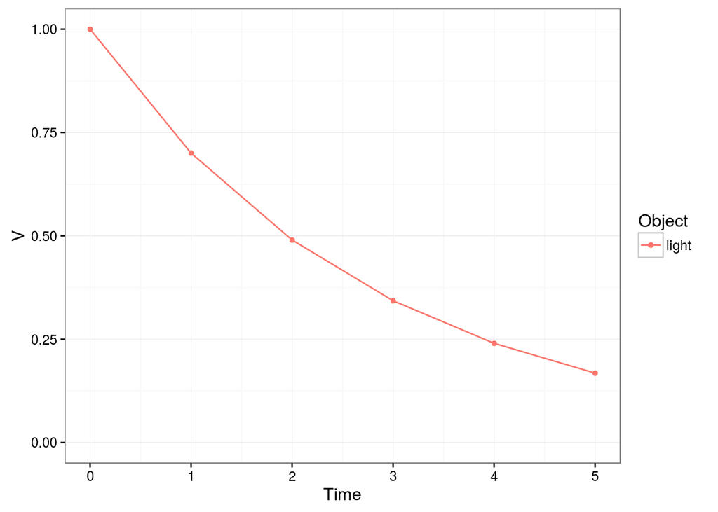

```r
ggplot(w[w$Object != '',], aes(Time, V, shape=Object, color=Object)) +
  geom_line() +
  geom_point() +
  theme_bw() + ylim(0, 1)
```